# Michigan PFAS Analysis

Author

Kabin, Nishan, Udita

Published

December 5, 2025

From the state of Michigan’s website:

*PFAS are a large group of man-made chemicals that include perfluorooctanoic acid (PFOA) and perfluorooctanesulfonic acid (PFOS). PFAS have been used globally during the past century in manufacturing, firefighting and thousands of common household and other consumer products. These chemicals are persistent in the environment and in the human body – meaning they don’t break down and they can accumulate over time. In recent years, experts have become increasingly concerned by the potential effects of high concentrations of PFAS on human health.*

PFAS contamination in West Michigan has unfortunately made headlines, reminiscent of other environmental advocacy efforts like that of renowned whistleblower **Erin Brockovich**.

There is a Michigan PFAS dataset available. This project in R focuses on analyzing the hazard index for the sites of interest and the samples taken from those sites and whether any trends and patterns appear in this dataset.

# Data Import and Data Dictionary

Importing the data from the csv files; there are four data files, two files (`sites_main` and `samples_main`) containing the data and two files (`data_dict_sites` and `data_dict_samples`) containing the data description .

```r
sites_main <- read_csv("data/pfas_sites.csv")
data_dict_sites <- read_csv("data/data_dict_sites.csv")
samples_main <- read_csv("data/pfas_hazard_index.csv")
data_dict_samples <- read_csv("data/data_dict_hazard.csv")
```

## Data dictionary for site

```r
data_type_sites <- tibble(Variable = names(sites_main), Type = map_chr(sites_main, typeof))

data_dict_sites <- left_join(data_dict_sites, data_type_sites, by = c("Variable"))
rm(data_type_sites)

data_dict_sites |>
  select(Variable, Type, Description) |>
  flextable() |>
  autofit()
```

| Variable | Type | Description |
| --- | --- | --- |
| geoid | double | Geographic region ID with the first 2 digits being the state Federal Information Processing Standard (FIPS) code and the last 3 digits the county FIPS code |
| longitude | double | Longitude coordinate of sample location |
| latitude | double | Latitude coordinate of sample location |
| facility | character | Name of the site |
| county | character | County where the site is located |
| address | character | Physical address of the project site |
| city | character | City where the project is physically located |
| zip_code | double | Zip code where the project is physically located |
| type | character | Describes the kind of site by type |
| residential_wells_sampled | character | Indicates whether residential wells have, or will be sampled (Domains = Yes, No, TBD, N/A) |
| site_lead | character | Name of contact person |
| site_lead_email | character | Contact person email |
| site_lead_phone | character | Contact person phone number |
| hyperlink | character | Web address to the site investigation summary |
| location | character | Geographic location description of the site |
| military | character | Indicates if the site is associated with the military |
| facility_date | character | Date the site was published on the Michigan PFAS Action Response Team website |
| site_background | character | Background information about the site |
| drinking_water_information | character | Information about drinking water quality and safety |
| anticipated_activities | character | The state of Michigan's planned or upcoming activities related to the site |

## Data dictionary for samples

```r
data_type_samples <- tibble(Variable = names(samples_main), Type = map_chr(samples_main, typeof))

data_dict_samples <- left_join(data_dict_samples, data_type_samples, by = c("Variable"))
rm(data_type_samples)

data_dict_samples |>
  select(Variable, Type, Description) |>
  flextable() |>
  autofit()
```

| Variable | Type | Description |
| --- | --- | --- |
| geoid | double | Geographic region ID with the first 2 digits being the state Federal Information Processing Standard (FIPS) code and the last 3 digits the county FIPS code |
| latitude | double | Sample site latitude |
| longitude | double | Sample site longitude |
| system_name | character | Name of water supply system |
| system_type | character | Type of water supply system |
| sample_date | character | The date that the sample was collected |
| pfhxs_result | double | PFHxS concentration in the sample measured in parts per trillion (ppt or ng/L) |
| pfna_result | double | PFNA concentration in the sample measured in parts per trillion (ppt or ng/L) |
| hfpoda_result | double | HFPO-DA concentration in the sample measured in parts per trillion (ppt or ng/L) |
| pfbs_result | double | PFBS concentration in the sample measured in parts per trillion (ppt or ng/L) |
| hazard_index | double | Hazard index |

## Patterns of missingness

```r
glimpse(sites_main)
```

```
Rows: 300
Columns: 20
$ geoid                      <dbl> 26081, 26081, 26039, 26103, 26069, 26087, 2…
$ longitude                  <dbl> -85.62169, -85.56018, -84.78779, -87.38730,…
$ latitude                   <dbl> 43.10536, 43.12251, 44.62668, 46.34960, 44.…
$ facility                   <chr> "Belmont - House St.", "Rockford Tannery", …
$ county                     <chr> "Kent County", "Kent County", "Crawford Cou…
$ address                    <chr> "1855 House Street", "123 North Main Street…
$ city                       <chr> "Rockford", "Rockford", "Grayling", "Gwinn"…
$ zip_code                   <dbl> 49341, 49341, 49738, 49841, 48750, 48446, 4…
$ type                       <chr> "Landfill", "Tannery", "Military", "Militar…
$ residential_wells_sampled  <chr> "Yes", "No", "Yes", "Yes", "Yes", "No", "No…
$ site_lead                  <chr> "Leah Gies", "Leah Gies", "Lisa Kruse", "Ke…
$ site_lead_email            <chr> "giesl1@michigan.gov", "giesl1@michigan.gov…
$ site_lead_phone            <chr> "616-215-4781", "616-215-4781", "989-370-14…
$ hyperlink                  <chr> "https://www.michigan.gov/pfasresponse/inve…
$ location                   <chr> "Rockford", "Rockford", "Grayling", "Gwinn"…
$ military                   <chr> "No", "No", "Yes", "Yes", "Yes", "No", "No"…
$ facility_date              <chr> NA, NA, NA, "2017/10/31 16:00:00+00", "2019…
$ site_background            <chr> NA, NA, NA, NA, NA, NA, NA, NA, NA, NA, NA,…
$ drinking_water_information <chr> NA, NA, NA, NA, NA, NA, NA, NA, NA, NA, NA,…
$ anticipated_activities     <chr> NA, NA, NA, NA, NA, NA, NA, NA, NA, NA, NA,…
```

```r
glimpse(samples_main)
```

```
Rows: 1,610
Columns: 11
$ geoid         <dbl> 39095, 26091, 26059, 26115, 26115, 18141, 18039, 26059, …
$ latitude      <dbl> 41.71705, 41.73054, 41.73360, 41.73989, 41.74204, 41.745…
$ longitude     <dbl> -83.51507, -84.21862, -84.41968, -83.56447, -83.66499, -…
$ system_name   <chr> "MONROE SOUTH COUNTY", "Morenci", "Waldron", "Monroe Sou…
$ system_type   <chr> "MUN", "MUN", "MUN", "MUN", "MUN", "MUN", "MUN", "MUN", …
$ sample_date   <chr> "2020/12/14 00:00:00+00", "2018/08/24 00:00:00+00", "201…
$ pfhxs_result  <dbl> 0, 0, 0, 0, 0, 0, 0, 0, 0, 0, 0, 0, 0, 0, 0, 0, 0, 0, 0,…
$ pfna_result   <dbl> 0, 0, 0, 0, 0, 0, 0, 0, 0, 0, 0, 0, 0, 0, 0, 0, 0, 0, 0,…
$ hfpoda_result <dbl> 0, 0, 0, 0, 0, 0, 0, 0, 0, 0, 0, 0, 0, 0, 0, 0, 0, 0, 0,…
$ pfbs_result   <dbl> 0, 0, 0, 0, 0, 4, 0, 0, 0, 0, 0, 0, 3, 0, 0, 0, 0, 0, 0,…
$ hazard_index  <dbl> 0.0000, 0.0000, 0.0000, 0.0000, 0.0000, 0.0020, 0.0000, …
```

```r
skim(sites_main)
```

Data summary

| Name | sites_main |
| --- | --- |
| Number of rows | 300 |
| Number of columns | 20 |
| _______________________ |  |
| Column type frequency: |  |
| character | 16 |
| numeric | 4 |
| ________________________ |  |
| Group variables | None |

**Variable type: character**

| skim_variable | n_missing | complete_rate | min | max | empty | n_unique | whitespace |
| --- | --- | --- | --- | --- | --- | --- | --- |
| facility | 0 | 1.00 | 9 | 103 | 0 | 300 | 0 |
| county | 0 | 1.00 | 10 | 26 | 0 | 76 | 0 |
| address | 1 | 1.00 | 4 | 88 | 0 | 299 | 0 |
| city | 1 | 1.00 | 4 | 29 | 0 | 174 | 0 |
| type | 0 | 1.00 | 7 | 22 | 0 | 15 | 0 |
| residential_wells_sampled | 0 | 1.00 | 2 | 3 | 0 | 4 | 0 |
| site_lead | 0 | 1.00 | 9 | 65 | 0 | 107 | 0 |
| site_lead_email | 0 | 1.00 | 15 | 27 | 0 | 128 | 0 |
| site_lead_phone | 0 | 1.00 | 12 | 16 | 0 | 105 | 0 |
| hyperlink | 0 | 1.00 | 84 | 134 | 0 | 293 | 0 |
| location | 115 | 0.62 | 4 | 25 | 0 | 128 | 0 |
| military | 0 | 1.00 | 2 | 4 | 0 | 3 | 0 |
| facility_date | 8 | 0.97 | 22 | 22 | 0 | 190 | 0 |
| site_background | 265 | 0.12 | 626 | 3752 | 0 | 35 | 0 |
| drinking_water_information | 265 | 0.12 | 95 | 2098 | 0 | 35 | 0 |
| anticipated_activities | 265 | 0.12 | 15 | 397 | 0 | 35 | 0 |

**Variable type: numeric**

| skim_variable | n_missing | complete_rate | mean | sd | p0 | p25 | p50 | p75 | p100 | hist |
| --- | --- | --- | --- | --- | --- | --- | --- | --- | --- | --- |
| geoid | 0 | 1 | 26088.58 | 45.84 | 26001.00 | 26049.00 | 26081.00 | 26125.00 | 26163.00 | ▃▅▇▆▆ |
| longitude | 0 | 1 | -84.82 | 1.32 | -90.13 | -85.70 | -84.76 | -83.66 | -82.44 | ▁▁▇▅▇ |
| latitude | 0 | 1 | 43.24 | 1.12 | 41.78 | 42.48 | 42.95 | 43.54 | 47.46 | ▇▆▂▁▁ |
| zip_code | 0 | 1 | 49003.64 | 3935.16 | 20020.00 | 48453.50 | 48911.00 | 49442.25 | 94105.00 | ▁▇▁▁▁ |

```r
skim(samples_main)
```

Data summary

| Name | samples_main |
| --- | --- |
| Number of rows | 1610 |
| Number of columns | 11 |
| _______________________ |  |
| Column type frequency: |  |
| character | 3 |
| numeric | 8 |
| ________________________ |  |
| Group variables | None |

**Variable type: character**

| skim_variable | n_missing | complete_rate | min | max | empty | n_unique | whitespace |
| --- | --- | --- | --- | --- | --- | --- | --- |
| system_name | 9 | 0.99 | 4 | 59 | 0 | 1527 | 0 |
| system_type | 0 | 1.00 | 3 | 7 | 0 | 12 | 0 |
| sample_date | 0 | 1.00 | 22 | 22 | 0 | 476 | 0 |

**Variable type: numeric**

| skim_variable | n_missing | complete_rate | mean | sd | p0 | p25 | p50 | p75 | p100 | hist |
| --- | --- | --- | --- | --- | --- | --- | --- | --- | --- | --- |
| geoid | 71 | 0.96 | 26119.63 | 1133.23 | 18039.00 | 26045.00 | 26081.00 | 26125.00 | 55037.00 | ▁▇▁▁▁ |
| latitude | 0 | 1.00 | 43.47 | 1.32 | 41.72 | 42.48 | 43.05 | 44.31 | 47.47 | ▇▅▃▂▁ |
| longitude | 0 | 1.00 | -84.99 | 1.30 | -90.17 | -85.77 | -84.96 | -84.01 | -82.38 | ▁▁▅▇▅ |
| pfhxs_result | 0 | 1.00 | 0.86 | 9.53 | 0.00 | 0.00 | 0.00 | 0.00 | 347.00 | ▇▁▁▁▁ |
| pfna_result | 0 | 1.00 | 0.05 | 0.96 | 0.00 | 0.00 | 0.00 | 0.00 | 34.00 | ▇▁▁▁▁ |
| hfpoda_result | 0 | 1.00 | 0.19 | 4.04 | 0.00 | 0.00 | 0.00 | 0.00 | 100.00 | ▇▁▁▁▁ |
| pfbs_result | 0 | 1.00 | 0.91 | 6.80 | 0.00 | 0.00 | 0.00 | 0.00 | 230.00 | ▇▁▁▁▁ |
| hazard_index | 0 | 1.00 | 0.11 | 1.04 | 0.00 | 0.00 | 0.00 | 0.00 | 34.72 | ▇▁▁▁▁ |

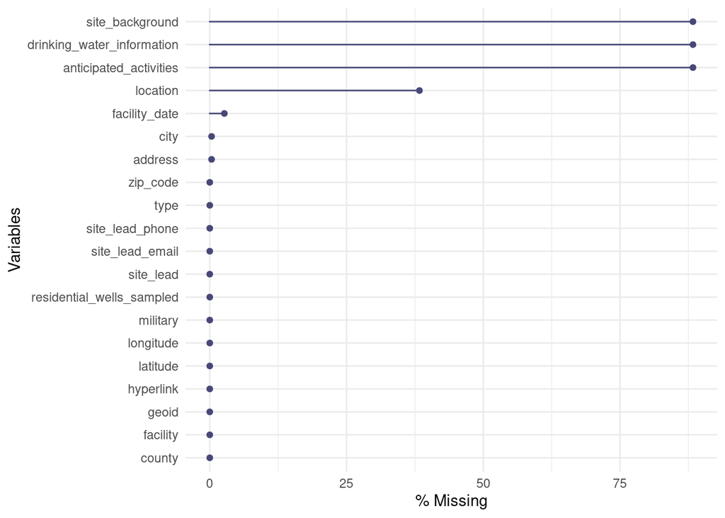

```r
gg_miss_var(sites_main, show_pct = TRUE)
```

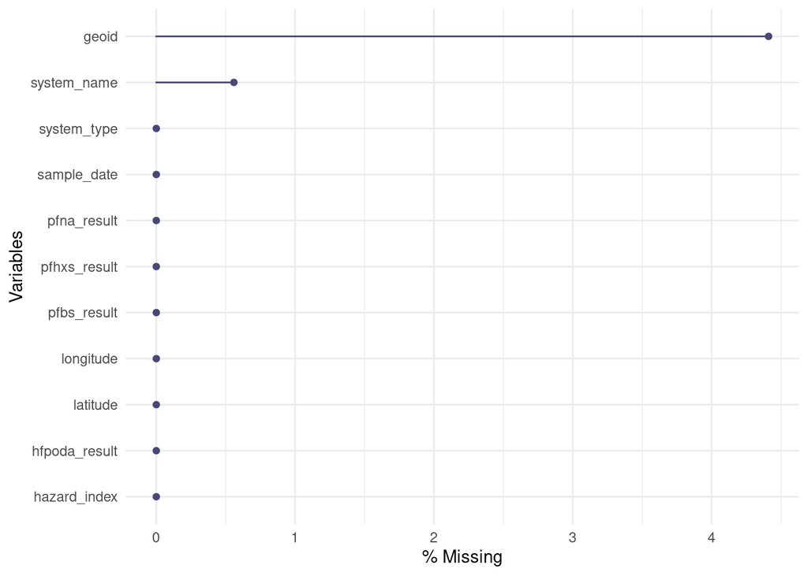

```r
gg_miss_var(samples_main, show_pct = TRUE)
```

Looking at these plots, it’s clear that some variables have too much missing data to be useful for our analysis. We decided to drop `site_background`, `drinking_water_information`, `anticipated_activities`, and `location` from the `pfas_sites` dataset because the gaps in these columns would just get in the way of our work.

```r
sites <- sites_main |>
  dplyr::select(-site_background, -drinking_water_information, -anticipated_activities, -location)

samples <- samples_main
```

From the data we can also see that around 70 samples don’t have geoids. Since they have the longitude and latitude information, let’s see where these samples were taken from the map, and see if we can infer geoid based on the location information.

Since these data have location information, let’s convert them to simple features object using the sf package.

```r
mi_counties <- counties(state="MI", cb = TRUE, year = 2024, class = "sf")

sites_sf <- sites |>
  st_as_sf(coords = c("longitude", "latitude"),
           crs = st_crs(mi_counties),   # WGS84
           remove = FALSE)

samples_sf <- samples |>
  st_as_sf(coords = c("longitude", "latitude"),
           crs = st_crs(mi_counties),
           remove = FALSE)
```

```r
samples_missing_geoid_sf <- samples_sf |>
  filter(is.na(geoid))
samples_present_geoid_sf <- samples_sf |>
  filter(!is.na(geoid))
```

```r
leaflet(options = leafletOptions(preferCanvas = TRUE)) |>
  addProviderTiles("CartoDB.Positron") |>  # nice clean basemap

  # Counties
  addPolygons(
    data = mi_counties,
    weight = 1,
    color = "#666666",
    fill = FALSE,
    opacity = 0.7,
    group = "Counties"
  ) |>

  # All points (faded background)
  addCircleMarkers(
    data = samples_present_geoid_sf,
    radius = 3,
    fillOpacity = 0.5,
    stroke = FALSE,
    color = "gray",
    group = "Points with GEOID"
  ) |>

  # Missing GEOID points (highlighted)
  addCircleMarkers(
    data = samples_missing_geoid_sf,
    radius = 3,
    fillOpacity = 0.8,
    stroke = TRUE,
    weight = 1,
    color = "red",
    popup = ~paste0(
      "<b>Hazard index:</b> ", hazard_index, "<br>",
      "<b>GEOID:</b> missing"
    ),
    group = "Missing GEOID"
  ) |>

  # Layers control
  addLayersControl(
    overlayGroups = c("Counties", "Points with GEOID", "Missing GEOID"),
    options = layersControlOptions(collapsed = TRUE),
    position = "topleft"
  ) |>


  # Color Legend
  addLegend(
    position = "bottomright",
    colors = c("gray", "red"),
    labels = c("No", "Yes"),
    title = "Missing GeoID",
    opacity = 1
  ) |>

  # Scale bar
  addScaleBar(position = "bottomleft") |>

  # Title
  addControl(
    "<h4>PFAS Sample Locations in Michigan</h4>",
    position = "topright"
  ) |>


  # Zoom to Michigan
  fitBounds(
    lng1 = min(samples_sf$longitude, na.rm = TRUE),
    lat1 = min(samples_sf$latitude, na.rm = TRUE),
    lng2 = max(samples_sf$longitude, na.rm = TRUE),
    lat2 = max(samples_sf$latitude, na.rm = TRUE)
  )
```

[interactive chart not shown]

From the above figure we can see that samples with missing geoid are the ones that lie just outside the border of the counties.

## Assign geoid of the nearest county to the samples

```r
nearest_idx <- st_nearest_feature(samples_missing_geoid_sf, mi_counties)

nearest_county <- mi_counties[nearest_idx, c("STATEFP", "COUNTYFP")]

samples_imputed_geoid_sf <- samples_missing_geoid_sf |>
  mutate(
    geoid = paste0(nearest_county$STATEFP, nearest_county$COUNTYFP) |> as.numeric()
  )

samples_sf <- bind_rows(samples_present_geoid_sf, samples_imputed_geoid_sf)
```

# Data Cleaning

## Data transformation and Merging

This approach required some assumptions about how samples relate to facilities, but it was necessary to get the two datasets linked together for analysis. Obviously, this introduces some uncertainty into the matching, but it was the best option we had given the data constraints.

```r
geo_ids <- unique(samples_sf$geoid)

# For each geoId, match samples to nearest site in that geoId
populate_nearest_facility <- function(samples, sites) {
  if (nrow(sites) == 0) {
    # No PFAS site in this county: keep NA
    samples$nearest_facility <- NA
    samples$distance_m      <- NA
  } else {
    # Index of nearest site in this county for each sample
    idx <- st_nearest_feature(samples, sites)

    samples$nearest_facility <- sites$facility[idx]

    # Distance to that nearest site (element-wise)
    samples$distance_m <- st_distance(samples, sites[idx, ],
                                        by_element = TRUE) |>
      as.numeric()
  }
  samples
}

samples_with_site <- map(geo_ids, function(g){
    samples_g <- samples_sf |> filter(geoid == g)
    sites_g   <- sites_sf   |> filter(geoid == g)

    return(populate_nearest_facility(samples_g, sites_g))
} )
```

```r
# Combine it into a single dataframe and convert back to tibble object
samples_with_site <- do.call(rbind, samples_with_site) |> st_drop_geometry()
```

```r
samples_site_df <- inner_join(samples_with_site, sites, by = c("nearest_facility" = "facility", "geoid"))
```

```r
#|echo: false

library(readr)

# Basic usage
write_csv(samples_site_df, "data/samples_site.csv")
```

## String Manipulation

```r
unique(samples_site_df$county)
```

```
 [1] "Lenawee County"          "Monroe County"
 [3] "Berrien County"          "St. Joseph County"
 [5] "Cass County"             "Washtenaw County"
 [7] "Jackson County"          "Calhoun County"
 [9] "Kalamazoo County"        "Van Buren County"
[11] "Van Buren  County"       "Wayne County"
[13] "Allegan County"          "Allegan  County"
[15] "Eaton County"            "Oakland County"
[17] "Oakland  County"         "Barry County"
[19] "Livingston County"       "Ingham County"
[21] "Macomb County"           "St. Clair County"
[23] "Saint Clair County"      "Clinton County"
[25] "Ionia County"            "Genesee County"
[27] "Kent County"             "Shiawassee County"
[29] "Ottawa  County"          "Ottawa County"
```

[output cut: 23 more lines]

We noticed that some counties - such as `Ottawa County`, `Allegan County`, and `Muskegon County` — were appearing as separate categories because of inconsistent spacing in their names. To clean this up and keep the data consistent, we applied `str_to_title()` to standardize casing and used `str_squish()` to remove any extra spaces in key text fields like `system_name`, `nearest_facility`, and `county`.

```r
samples_site_df <- samples_site_df |>
  mutate(system_name = str_squish(str_to_title(system_name)),
         nearest_facility = str_squish(str_to_title(nearest_facility)),
         county = str_squish(str_to_title(county)))
```

## Date time functions

In the following step, we are converting the `sample_date` and `facility_date` columns from character strings to date-time format using the `ymd_hms()` function. After inspecting the data, we noticed that most entries were missing the hours, minutes, and seconds component, so we opted to extract only the year, month, and day using the `ymd()` function.

```r
#|warning: false

#Before
print(str_glue("Type of sample_date before conversion:{typeof(samples_site_df$sample_date)}"))
```

```
Type of sample_date before conversion:character
```

```r
samples_site_df <- samples_site_df |>
  mutate(sample_date = ymd(ymd_hms(sample_date)),
         facility_date =ymd(ymd_hms(facility_date)))

print(str_glue("Type of sample_date after conversion: {typeof(samples_site_df$sample_date)}"))
```

```
Type of sample_date after conversion: double
```

In the following step, we are creating a new column, `years_since_sample`, which calculates how many years have passed since each water sample was collected. This helps quantify the age of each sample, which can be important for analyzing trends over time, understanding the relevance of the `hazard_index`, and identifying whether older samples might need to be prioritized for re-sampling or further investigation.

```r
samples_site_df <- samples_site_df |>
  mutate(years_since_sample =  interval(sample_date, today()) / years(1))
```

# Exploratory Data Analysis

This analysis identifies counties with the highest hazard index values. We filtered for samples exceeding a hazard index of 1, grouped by county, and extracted the maximum hazard index for each. Counties are ranked by their peak contamination level, giving us a quick view of which areas have the most severe contamination.

```r
samples_site_df |>
  filter(hazard_index > 1) |>
  group_by(county) |>
  summarize(max_hazard_index = max(hazard_index, na.rm = TRUE)) |>
  arrange(-max_hazard_index) |>
  flextable() |>
  autofit()
```

| county | max_hazard_index |
| --- | --- |
| Emmet County | 34.72050 |
| Grand Traverse County | 10.00000 |
| Manistee County | 9.30000 |
| Ottawa County | 6.71500 |
| Kent County | 6.20300 |
| Montcalm County | 5.10000 |
| Kalamazoo County | 4.80600 |
| Marquette County | 4.50100 |
| Chippewa County | 4.00000 |
| Leelanau County | 3.90150 |
| Oakland County | 3.60400 |
| Calhoun County | 2.20000 |
| Iosco County | 2.20000 |
| Montmorency County | 2.10250 |
| Allegan County | 1.91450 |
| Jackson County | 1.90115 |
| Crawford County | 1.80000 |
| Isabella County | 1.70200 |
| Lake County | 1.50200 |
| Clare County | 1.20300 |
| Muskegon County | 1.10000 |
| Newaygo County | 1.00150 |

Here, we are exploring the total number of samples taken in each county. Higher values of n indicates higher sampling effort in the county.

```r
samples_site_df |>
  count(county) |>
  arrange(-n)
```

```
# A tibble: 67 × 2
   county                n
   <chr>             <int>
 1 Oakland County       80
 2 Allegan County       58
 3 Kent County          48
 4 Jackson County       45
 5 Livingston County    45
 6 Berrien County       42
 7 Genesee County       42
 8 Kalamazoo County     40
 9 Washtenaw County     34
10 St. Joseph County    33
# ℹ 57 more rows
```

From the table above, it can be seen that the Oakland county has highest sampling effort followed by Allegan, Kent, Jackson and so on.

## Tables of Summary Statistics

We are exploring county-level summary of the drinking water sample data in the following step. Using `group_by()` and `summarise()`, we calculated key statistics (mean, standard deviation, median, max, min) for each county.

```r
#County level summary statistics
county_summary <- samples_site_df |>
  group_by(county) |>
  summarise( n_sites = n(),
            mean_hi = round(mean(hazard_index, na.rm = TRUE), digits = 2),
            std_hi = round(sd(hazard_index, na.rm = TRUE), digits = 2),
            median_hi = round(median(hazard_index, na.rm = TRUE), digits = 2),
            max_hi = round(max(hazard_index, na.rm = TRUE), digits = 2),
            min_hi = round(min(hazard_index, na.rm = TRUE), digits = 2)) |>
  arrange(-n_sites)

# Identifying counties where all water samples have a hazard index of zero
for (i in 1:nrow(county_summary))
{
  if (county_summary$max_hi[i] == 0) {
    print(str_glue("All the samples in {county_summary$county[i]} have 0 hazard index."))
  }
}
```

```
All the samples in Genesee County have 0 hazard index.
All the samples in Ingham County have 0 hazard index.
All the samples in Lapeer County have 0 hazard index.
All the samples in Lenawee County have 0 hazard index.
All the samples in Sanilac County have 0 hazard index.
All the samples in Macomb County have 0 hazard index.
All the samples in Shiawassee County have 0 hazard index.
All the samples in Clinton County have 0 hazard index.
All the samples in St. Clair County have 0 hazard index.
All the samples in Cheboygan County have 0 hazard index.
All the samples in Huron County have 0 hazard index.
All the samples in Missaukee County have 0 hazard index.
All the samples in Houghton County have 0 hazard index.
All the samples in Alger County have 0 hazard index.
All the samples in Gratiot County have 0 hazard index.
All the samples in Mackinac County have 0 hazard index.
All the samples in Kalkaska County have 0 hazard index.
All the samples in Menominee County have 0 hazard index.
All the samples in Alcona County have 0 hazard index.
All the samples in Gogebic County have 0 hazard index.
All the samples in Alpena County have 0 hazard index.
All the samples in Schoolcraft County have 0 hazard index.
All the samples in Bay County have 0 hazard index.
All the samples in Saint Clair County have 0 hazard index.
```

This output has highlighted the county with no explicitly detected hazards, which means that these counties do not pose a measurable health risk according to EPA guidelines. Also, high standard deviation in some county suggests that mean hazard index might not accurately represent what is happening at most sites i.e. some samples might have much higher hazard indices than others, suggesting uneven contamination.

```r
county_summary
```

```
# A tibble: 67 × 7
   county            n_sites mean_hi std_hi median_hi max_hi min_hi
   <chr>               <int>   <dbl>  <dbl>     <dbl>  <dbl>  <dbl>
 1 Oakland County         80    0.12   0.58         0   3.6       0
 2 Allegan County         58    0.06   0.28         0   1.91      0
 3 Kent County            48    0.19   0.9          0   6.2       0
 4 Jackson County         45    0.06   0.29         0   1.9       0
 5 Livingston County      45    0.03   0.09         0   0.5       0
 6 Berrien County         42    0.02   0.1          0   0.6       0
 7 Genesee County         42    0      0            0   0         0
 8 Kalamazoo County       40    0.29   0.94         0   4.81      0
 9 Washtenaw County       34    0.01   0.05         0   0.3       0
10 St. Joseph County      33    0.02   0.09         0   0.4       0
# ℹ 57 more rows
```

The following exploration highlights the sites in the Kent county where at least one sample has a non-zero hazard index.

```r
kent_county_sites <- samples_site_df |>
  dplyr::filter(county == "Kent County") |>
  group_by(nearest_facility) |>
  summarise(n_samples = n(),
            mean_hi = round(mean(hazard_index, na.rm = TRUE), digits = 2),
            std_hi = round(sd(hazard_index, na.rm = TRUE), digits = 2),
            median_hi = round(median(hazard_index, na.rm = TRUE), digits = 2),
            max_hi = round(max(hazard_index, na.rm = TRUE), digits = 2),
            min_hi = round(min(hazard_index, na.rm = TRUE), digits = 2) )


kent_county_sites |>
  filter(!(max_hi == 0)) |>
  flextable() |>
  set_caption("Table 1: Summary statistics for sites in Kent county")
```

| nearest_facility | n_samples | mean_hi | std_hi | median_hi | max_hi | min_hi |
| --- | --- | --- | --- | --- | --- | --- |
| Ashley Avenue Disposal Area | 4 | 0.05 | 0.10 | 0.00 | 0.20 | 0.00 |
| Belmont - House St. | 2 | 0.32 | 0.03 | 0.32 | 0.34 | 0.30 |
| Caledonia Wastewater Treatment Plant | 5 | 1.24 | 2.77 | 0.00 | 6.20 | 0.00 |
| Cedar Springs Historic Wastewater Treatment Lagoons And Discharge Fields | 9 | 0.03 | 0.10 | 0.00 | 0.30 | 0.00 |
| Gerald R. Ford International Airport | 2 | 0.10 | 0.15 | 0.10 | 0.21 | 0.00 |
| Northeast Gravel | 2 | 0.25 | 0.36 | 0.25 | 0.50 | 0.00 |
| Sparta Foundry Waste Facility | 8 | 0.08 | 0.23 | 0.00 | 0.66 | 0.00 |
| State Disposal Superfund | 2 | 0.10 | 0.14 | 0.10 | 0.20 | 0.00 |
| Wolverine Sole Plant (Former) | 1 | 0.22 |  | 0.22 | 0.22 | 0.22 |

Displaying the county having `hazard_index` greater than 1.

```r
county_summary |>
  dplyr::filter(max_hi > 1) |>
  arrange(-max_hi) |>
  slice_head(n = 15) |>
  flextable() |>
  set_caption("Table 2: Summary statistics of counties having hazard index greater than one")
```

| county | n_sites | mean_hi | std_hi | median_hi | max_hi | min_hi |
| --- | --- | --- | --- | --- | --- | --- |
| Emmet County | 21 | 1.72 | 7.56 | 0 | 34.72 | 0 |
| Grand Traverse County | 24 | 0.84 | 2.64 | 0 | 10.00 | 0 |
| Manistee County | 17 | 0.56 | 2.25 | 0 | 9.30 | 0 |
| Ottawa County | 29 | 0.39 | 1.36 | 0 | 6.72 | 0 |
| Kent County | 48 | 0.19 | 0.90 | 0 | 6.20 | 0 |
| Montcalm County | 21 | 0.28 | 1.11 | 0 | 5.10 | 0 |
| Kalamazoo County | 40 | 0.29 | 0.94 | 0 | 4.81 | 0 |
| Marquette County | 28 | 0.21 | 0.86 | 0 | 4.50 | 0 |
| Chippewa County | 15 | 0.30 | 1.03 | 0 | 4.00 | 0 |
| Leelanau County | 22 | 0.21 | 0.83 | 0 | 3.90 | 0 |
| Oakland County | 80 | 0.12 | 0.58 | 0 | 3.60 | 0 |
| Calhoun County | 28 | 0.14 | 0.47 | 0 | 2.20 | 0 |
| Iosco County | 9 | 0.29 | 0.73 | 0 | 2.20 | 0 |
| Montmorency County | 4 | 0.53 | 1.05 | 0 | 2.10 | 0 |
| Allegan County | 58 | 0.06 | 0.28 | 0 | 1.91 | 0 |

High standard deviation in some county suggests that mean hazard index might not accurately represent what is happening at most sites i.e. some samples might have much higher hazard indices than others, suggesting uneven contamination. In the above table, `n` represents the total number od drinking water sample in each county. Even if the median is low in some counties, the maximum value shows the worst-case exposure, which is critical for environmental health assessments as it helps to identify hotspots or locations needing urgent attention.

## Data Visualizations

### Distribution of hazard index

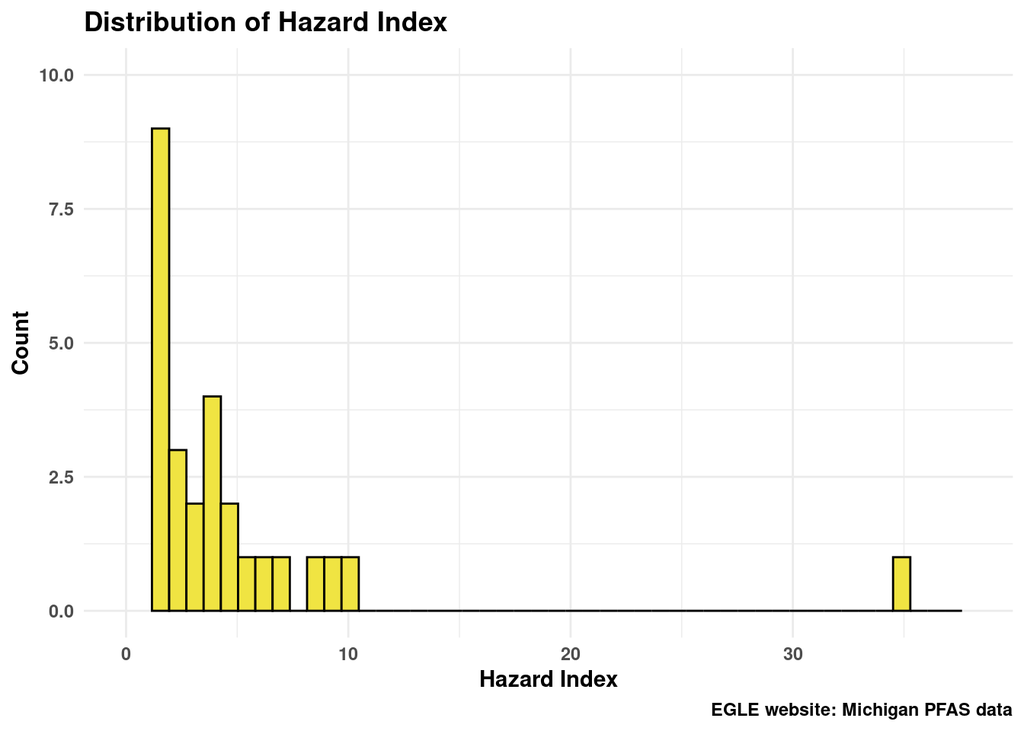

```r
dist_hazard <- samples_site_df |>
  ggplot( aes(hazard_index)) +
  geom_histogram(color = "black", fill = "#F0E442", bins = 50) +
  scale_x_continuous(limits =  c(0,38)) +
  scale_y_continuous(limits =  c(0,10)) +
  theme_minimal() +
  labs(title = "Distribution of Hazard Index",
       x = "Hazard Index",
       y = "Count",
       caption = "EGLE website: Michigan PFAS data") +
  theme(text = element_text(face = "bold"))

dist_hazard
```

### Visualizing number of samples for each county based on the area

```r
mi_counties <- mi_counties |>
  mutate(area_km2 = as.numeric(st_area(geometry)) / 1e6)

#Samples count per county
sample_count <- samples_site_df |>
  mutate(
    county = str_replace(county, "Saint Clair County", "St. Clair County"),
    county = str_replace(county, "Oceana & Newaygo County", "Newaygo County")
  ) |>
  group_by(county, geoid) |>
  summarise(n_samples = n())
```

```r
sample_count <- sample_count |>
  mutate(geoid = as.character(geoid))
```

```r
# Merging area + sample counts
county_sampling <- mi_counties |>
  select(NAME, GEOID, area_km2) |>
  left_join(sample_count, by = c("GEOID" = "geoid"))
```

```r
# creating sampling density
county_sampling <- county_sampling |>
  mutate(samples_per_100sqkm = n_samples / (area_km2 / 100))
```

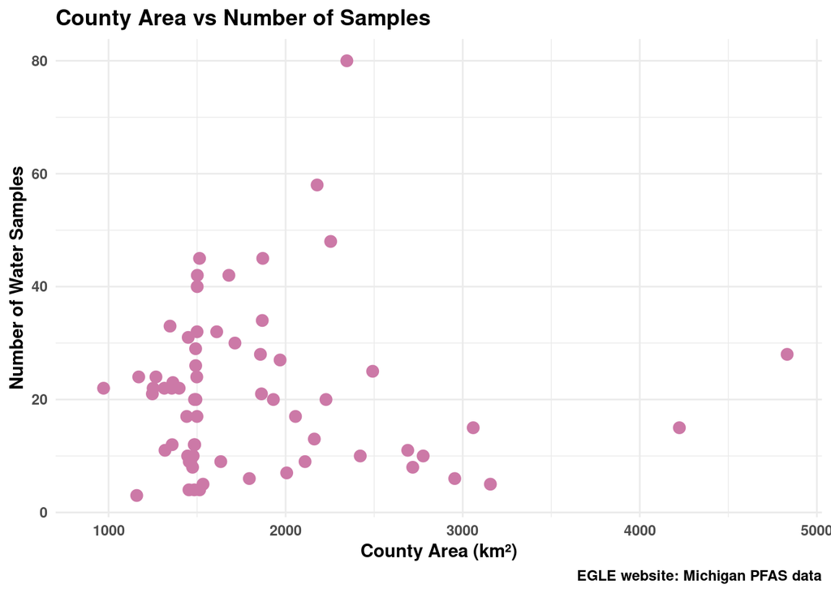

```r
ggplot(county_sampling, aes(x = area_km2, y = n_samples)) +
  geom_point(size = 3, color = "#CC79A7") +
  labs(title = "County Area vs Number of Samples",
    x = "County Area (km²)",
    y = "Number of Water Samples",
    caption = "EGLE website: Michigan PFAS data") +
  theme_minimal() +
  theme(text = element_text(face = "bold"))
```